# Question

A circle with radius $R=6$ ft is cut to a sector with an angle of $\theta=\frac{6\pi}{5}$ radians.

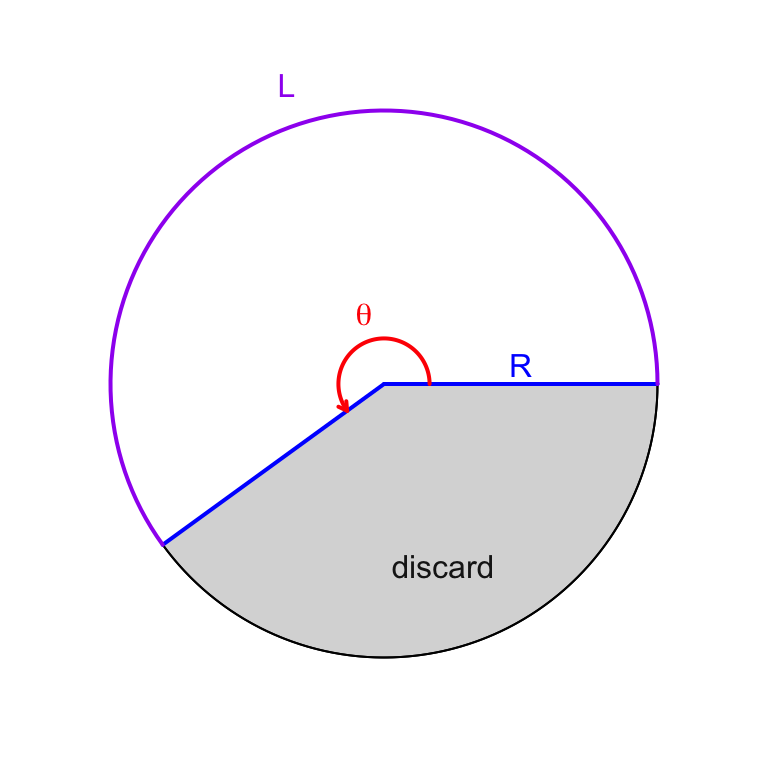

By connecting the initial side and terminal side, the sector is bent (in 3 dimensions) into a [right-circular cone](https://en.wikipedia.org/wiki/Cone) with height $h$ and radius $r$. Notice the cone’s [slant height](https://en.wikipedia.org/wiki/Cone#Slant_height) equals the radius of the original circle ($R$) and the circumference of the cone matches the arc length ($L$) of the original circle.

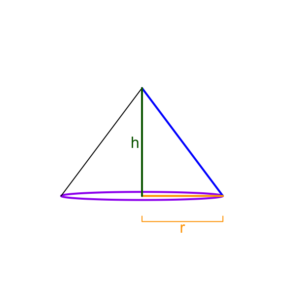

Find the ratio of the cone’s height to the cone’s radius.

$$\frac{h}{r} ~=~ ?$$

The tolerance is $\pm 0.01$.

# Solution

First, find the arc length.

$$L ~=~ \frac{6\pi}{5} \cdot 6 ~=~
\frac{36\pi}{5}$$

We know that a circle’s circumference is twice its radius times $\pi$. Look at the circular base of the cone, and use the circumference formula to find its radius. Remember $L$ is the circumference of the cone’s base.

$$L=2\pi r$$

Divide both sides by $2\pi$ and switch sides to get $r=\frac{L}{2\pi}$.

$$r ~=~ \frac{L}{2\pi} ~=~
\frac{\frac{36\pi}{5}}{2\pi}$$

$$r ~=~ \frac{18}{5}$$

To get the height of the cone, use [Pythagorean theorem](https://en.wikipedia.org/wiki/Pythagorean_theorem), which states a right triangle with legs $a$ and $b$ and hypotenuse $c$ is constrained by $a^2+b^2=c^2$.

$$\left(\frac{18}{5}\right)^2 + h^2 =
(6)^2$$

Solve for $h$.

$$h =
\sqrt{(6)^2-\left(\frac{18}{5}\right)^2}$$

$$h\approx 4.8$$

Find the ratio.

$$\frac{h}{r} ~=~
\frac{\sqrt{(6)^2-\left(\frac{18}{5}\right)^2}}{\frac{18}{5}}$$

$$\frac{h}{r} \approx
1.3333333$$

### Fancy stuff

With some thought, you might convince yourself that this ratio $\frac{h}{r}$ should be independent of the radius of the original circle. For example, if you measured the radius $R$ in inches (instead of feet), the $\frac{h}{r}$ ratio shouldn’t change. Or if you doubled $R$, it seems $\frac{h}{r}$ should be the same.

By approaching this problem more algebraically, you might reach some interesting insights. For example, if we define $f$ to be the fraction of the original circle.

$$f = \frac{\theta}{2\pi}$$

You can show that the ratio of radii also equals $f$.

$$\frac{r}{R} = f$$

Substituting $r=Rf$, you can generalize the formula to find $h$ in terms of $R$ and $f$:
$$h ~=~
\sqrt{R^2-r^2} ~=~ \sqrt{R^2-(fR)^2} ~=~ R\sqrt{1-f^2}$$

Using that information, you can derive a simple formula for $\frac{h}{r}$ that only depends on $f$.

# Meta-information

extype: num exsolution: 1.3333333 exname: conical_ratio extol: 0.01